# 07-logistic_regression

Katherine Goode

March 12, 2019

# Overview

I have been thinking a lot about it is difficult to determine whether LIME is providing reasonable explanations, because we cannot know what the random forest is doing. That is the point of LIME. Heike suggested that we fit a logistic regression model to the training bullet data. We can then apply LIME to the logistic regression and determine if the explanations match what we would expect based on the coefficients of the logistic regression that we can interpret. She also suggested including interactions in the logistic regression model. This journal goes through the process of fitting several logisitic regression models, applying LIME to them, and comparing the results.

```r
# Load libraries
library(furrr)
library(future)
library(glmnet)
library(gretchenalbrecht)
library(hierNet)
library(lime)
library(tidyverse)

# Source functions
source("../../code/helper_functions.R")
```

# The Data

The cleaned training and testing datasets are loaded in below.

```r
# Load in the training data (Hamby Data 173 and 252)
hamby173and252_train <- read.csv("../../data/hamby173and252_train.csv")

# Load in the testing data (Hamby Data 224 Sets 1 and 11)
hamby224_test <- read.csv("../../data/hamby224_test.csv")
```

A vector containing the features used in the random forest `rtrees` is created below that will be used when creating some of the plots in this journal.

```r
# Obtain features used when fitting the rtrees random forest
rf_features <- rownames(bulletr::rtrees$importance)
```

# Logistic Regression Models

### Main Effects Only

The code below fits a logistic regression model to the training data using the `train` function from the caret package. The nine features used to fit `rtrees` are included as main effects only. The features are standardized prior to fitting the model using the `preProcess = "scale"` in `train`.

```r
# Fit or load the logistic regression model with only main effects
if(!file.exists("./data/logistic_mains.rds")) {

  # Set a seed
  set.seed(20190226)

  # Fit the model
  logistic_mains <- caret::train(as.factor(samesource) ~ ccf + rough_cor + D + sd_D +
                                   matches + mismatches + cms + non_cms + sum_peaks,
                                 preProcess = "scale",
                                 data = hamby173and252_train,
                                 method = "glm",
                                 family = "binomial")

  # Save the model
  saveRDS(logistic_mains, "./data/logistic_mains.rds")

} else{

  # Load the model
  logistic_mains <- readRDS("./data/logistic_mains.rds")

}
```

The output from the model is shown below. The features of ccf and matches stand out as the most important features in the model.

```r
# Summary of the model
summary(logistic_mains)
```

```
##
## Call:
## NULL
##
## Deviance Residuals:
##     Min       1Q   Median       3Q      Max
## -1.6617  -0.0759  -0.0416  -0.0239   4.8101
##
## Coefficients:
##              Estimate Std. Error z value Pr(>|z|)
## (Intercept) -10.02313    0.41486 -24.160  < 2e-16 ***
## ccf           1.52843    0.05079  30.093  < 2e-16 ***
## rough_cor    -0.06387    0.06440  -0.992 0.321335
## D             0.78418    0.07803  10.049  < 2e-16 ***
## sd_D         -0.30758    0.07974  -3.857 0.000115 ***
## matches       1.32252    0.09455  13.987  < 2e-16 ***
## mismatches   -1.07490    0.08229 -13.062  < 2e-16 ***
## cms          -0.07989    0.06169  -1.295 0.195318
## non_cms       0.81650    0.09165   8.909  < 2e-16 ***
## sum_peaks    -0.22886    0.07115  -3.216 0.001298 **
## ---
## Signif. codes:  0 '***' 0.001 '**' 0.01 '*' 0.05 '.' 0.1 ' ' 1
##
## (Dispersion parameter for binomial family taken to be 1)
##
##     Null deviance: 12728.0  on 83027  degrees of freedom
## Residual deviance:  4231.3  on 83018  degrees of freedom
## AIC: 4251.3
##
## Number of Fisher Scoring iterations: 9
```

### All Two Way Interactions

The code below fits a logistic regression model to the training data using the `train` function from the caret package. The nine features used to fit `rtrees` are included as main effects and with all two way interactions. The features are standardized prior to fitting the model using the `preProcess = "scale"` in `train`.

```r
# Fit or load the logistic regression model with all two way interactions
if(!file.exists("./data/logistic_inters2.rds")) {

  # Set a seed
  set.seed(20190226)

  # Fit the model
  logistic_inters2 <- caret::train(as.factor(samesource) ~
                                       (ccf + rough_cor + D + sd_D + matches +
                                          mismatches + cms + non_cms + sum_peaks)^2,
                                     preProcess = "scale",
                                     data = hamby173and252_train,
                                     method = "glm",
                                     family = "binomial")

  # Save the model
  saveRDS(logistic_inters2, "./data/logistic_inters2.rds")

} else{

  # Load the model
  logistic_inters2 <- readRDS("./data/logistic_inters2.rds")

}
```

The output from this model is not shown.

```r
# Summary of the model
summary(logistic_inters2)
```

### LASSO Model

```r
# Fit or load the lasso logistic regression model
if(!file.exists("./data/logistic_lasso.rds")) {

  # Set a seed
  set.seed(20190312)

  # LASSO logistic regression model
  logistic_lasso <- cv.glmnet(x = hamby173and252_train %>% select(rf_features) %>% as.matrix(ncol = 9),
                              y = hamby173and252_train %>% pull(samesource) %>% as.numeric(),
                              alpha = 1,
                              family = "binomial")

  # Tell R to run the upcoming code in parallel
  # plan(multiprocess)

  # LASSO logistic regression model with possible pairwise interactions
  # logistic_lasso <-
  #   hierNet.logistic.path(x = hamby173and252_train %>% select(rf_features) %>% as.matrix(ncol = 9),
  #                         y = hamby173and252_train %>% pull(samesource) %>% as.numeric(),
  #                         lamlist = logistic_lasso$lambda)

  # Save the model
  saveRDS(logistic_lasso, "./data/logistic_lasso.rds")

} else {

  # Load the model
  logistic_lasso <- readRDS("./data/logistic_lasso.rds")

}
```

### Comparing the Models

The results as computed by caret on the training data are shown below for the two logistic regression models. The accuracy shows that the models with two way interactions performs better on the training data.

```r
# Results from the models
data.frame(model = c("mains", "inters2")) %>%
  bind_cols(bind_rows(logistic_mains$results, logistic_inters2$results))
```

```
##     model parameter  Accuracy     Kappa   AccuracySD    KappaSD
## 1   mains      none 0.9948650 0.7874929 0.0003508790 0.01509968
## 2 inters2      none 0.9954217 0.8178426 0.0003020483 0.01219222
```

The AICs from the models are shown below. The model with two way interactions performs the best based on AIC.

```r
AIC(logistic_mains$finalModel)
```

```
## [1] 4251.283
```

```r
AIC(logistic_inters2$finalModel)
```

```
## [1] 3589.68
```

I also wanted to know how the models perform on the test data. The models are used to make predictions on the test data and the MSEs are computed for each model. These are shown in the table below. The model with main effects only has the smallest MSE. I am guessing that the other model is overfitting the data.

```r
data.frame(obs = hamby224_test %>%
             pull(samesource) %>% na.omit(),
           mains = predict(logistic_mains, hamby224_test %>% select(rf_features)),
           inters2 = predict(logistic_inters2, hamby224_test %>% select(rf_features))) %>%
  mutate(mains_sqerrs = (obs - as.logical(mains))^2,
         inters2_sqerrs = (obs - as.logical(inters2))^2) %>%
  summarise_at(vars(mains_sqerrs, inters2_sqerrs),
               function(x) sum(x) / length(x)) %>%
  rename(mains_mse = mains_sqerrs, inters2_mse = inters2_sqerrs)
```

```
##    mains_mse inters2_mse
## 1 0.01098901  0.02197802
```

# Applying LIME to the Models

### Default LIME Applied to Main Effects Model

The functions `lime` and `explain` from the lime package are applied below to the logisitc regression model with only main effects.

```r
# Create or load the lime and explain objects for the main effects logisitic regression model
if(!file.exists("./data/lime_explain_mains.rds")) {

  # Set a seed
  set.seed(20190226)

  # Apply lime
  lime_mains <- lime(x = hamby173and252_train %>% select(rf_features),
                     model = logistic_mains)

  # Apply explain
  explain_mains <- explain(x = hamby224_test %>%
                             select(rf_features) %>%
                             na.omit(),
                           explainer = lime_mains,
                           n_labels = 1,
                           n_features = 3)

  # Join the lime and explain objects in a list
  lime_explain_mains <- list(lime = lime_mains, explain = explain_mains)

  # Save the lime and explain objects
  saveRDS(lime_explain_mains, "./data/lime_explain_mains.rds")

} else {

  # Load the lime and explain objects
  lime_explain_mains <- readRDS("./data/lime_explain_mains.rds")

}
```

### All Input Options of LIME Applied to Main Effects Model

The code below applies the LIME algorithm to the main effects logisitic regression model one time for the following different input cases:

- 2 to 6 quantile bins
- 2 to 6 equally spaced bins
- 2 to 6 tree based bins with `samesource` as the response variable
- 2 to 6 tree based bins with `rfscore` as the response variable
- kernel density estimation
- normal density approximation

It applies LIME using my function `run_lime` to specify the different input values. The outputs from the `lime` function are combined into a list, and the outputs from the `explain` function are combined into dataframe. Both are saved as .rds files.

```r
# Apply the run_lime function if the lime results file does not already exist
if(!file.exists("./data/logistic_lime_inputs.rds")) {

  # Specify the input options to use with lime
  logistic_lime_inputs <- list(bin_continuous = c(rep(TRUE, 20),
                                                  rep(FALSE, 2)),
                               quantile_bins = c(rep(TRUE, 5),
                                                 rep(FALSE, 5),
                                                 rep(TRUE, 12)),
                               nbins = c(rep(2:6, 4),
                                         rep(4, 2)),
                               use_density = c(rep(TRUE, 20), TRUE, FALSE),
                               bin_method = c(rep("quantile_bins", 5),
                                              rep("equally_spaced", 5),
                                              rep("tree", 10),
                                              rep("quantile_bins", 2)),
                               response = c(rep(NA, 10),
                                            rep("samesource", 5),
                                            rep("rfscore", 5),
                                            rep(NA, 2)))

  # Tell R to run the upcoming code in parallel
  plan(multiprocess)

  # Apply lime to the full training data with the specified input options
  logistic_lime_explain <- future_pmap(.l = logistic_lime_inputs,
             .f = run_lime, # run_lime is one of my helper functions
             features = rf_features,
             train = hamby173and252_train,
             test = hamby224_test %>%
               arrange(case) %>%
               select(rf_features) %>%
               na.omit(),
             rfmodel = logistic_mains,
             label = "TRUE",
             nfeatures = 3,
             seed = TRUE)

  # Separate the lime and explain function results from the full data
  logistic_lime <- map(logistic_lime_explain, function(list) list$lime)
  logistic_explain <- map_df(logistic_lime_explain, function(list) list$explain)

  # Name the items in the lime list
  names(logistic_lime) <- map_chr(1:22, function(case)
      sprintf("case: bin_continuous = %s, quantile_bins = %s, nbins = %0.f, use_density = %s, bin_method = %s, response = %s",
              logistic_lime_inputs$bin_continuous[case],
              logistic_lime_inputs$quantile_bins[case],
              logistic_lime_inputs$nbins[case],
              logistic_lime_inputs$use_density[case],
              logistic_lime_inputs$bin_method[case],
              logistic_lime_inputs$response[case]))

  # Turn the lime input options into a dataframe before saving it
  logistic_lime_inputs <- logistic_lime_inputs %>%
    unlist() %>%
    matrix(ncol = length(logistic_lime_inputs),
           dimnames = list(NULL, names(logistic_lime_inputs))) %>%
    as.data.frame() %>%
    mutate(case = 1:length(logistic_lime_inputs$quantile_bins)) %>%
    select(case, bin_continuous:response)

  # Save the lime objects
  saveRDS(logistic_lime_inputs, "./data/logistic_lime_inputs.rds")
  saveRDS(logistic_lime, "./data/logistic_lime.rds")
  saveRDS(logistic_explain, "./data/logistic_explain.rds")

} else {

  # Load in the lime objects
  logistic_lime_inputs <- readRDS("./data/logistic_lime_inputs.rds")
  logistic_lime <- readRDS("./data/logistic_lime.rds")
  logistic_explain <- readRDS("./data/logistic_explain.rds")

}
```

```r
# Create the test_explain combined data if the file does not already exist
if(!file.exists("./data/logistic_test_explain.rds")) {

  # Join the data and the explanations and edit and add additional variables
  logistic_test_explain <- hamby224_test %>%
    mutate(case = as.character(case)) %>%
    full_join(logistic_explain, by = "case") %>%
    mutate(case = factor(case),
           feature_desc = factor(feature_desc),
           feature = factor(feature),
           nbins = factor(nbins)) %>%
    arrange(nbins) %>%
    mutate(nbins = as.numeric(as.character(nbins)),
           situation = ifelse(bin_continuous == TRUE & bin_method == "quantile_bins",
                              sprintf("%.0f quantile", nbins),
                              ifelse(bin_continuous == TRUE & bin_method == "equally_spaced",
                                     sprintf("%.0f equally spaced", nbins),
                                     ifelse(bin_continuous == TRUE & bin_method == "tree" &
                                              response == "samesource",
                                            sprintf("%.0f samesource tree", nbins),
                                            ifelse(bin_continuous == TRUE & bin_method == "tree" &
                                              response == "rfscore",
                                              sprintf("%.0f rfscore tree", nbins),
                                              ifelse(bin_continuous == FALSE &
                                                     use_density == TRUE,
                                                     "kernel density",
                                                     "normal approximation"))))) %>%
             fct_relevel("2 quantile", "3 quantile", "4 quantile",
                         "5 quantile", "6 quantile", "2 equally spaced",
                         "3 equally spaced", "4 equally spaced",
                         "5 equally spaced", "6 equally spaced",
                         "2 samesource tree", "3 samesource tree",
                         "4 samesource tree", "5 samesource tree",
                         "6 samesource tree")) %>%
    mutate(bin_situation = ifelse(bin_method == "quantile_bins" &
                                  bin_continuous == TRUE,
                                  "quantile",
                                  ifelse(bin_method == "equally_spaced" &
                                         bin_continuous == TRUE,
                                         "equally spaced",
                                         ifelse(bin_method == "tree" &
                                                bin_continuous == TRUE &
                                                response == "samesource",
                                                "samesource tree",
                                                ifelse(bin_method == "tree" &
                                                       bin_continuous == TRUE &
                                                       response == "rfscore",
                                                       "rfscore tree",
                                                       ifelse(bin_continuous == FALSE &
                                                       use_density == TRUE,
                                                       "kernel density",
                                                       "normal approximation")))))) %>%
    mutate(bin_situation = factor(bin_situation))

  # Save the combined test and explain data
  saveRDS(logistic_test_explain, "./data/logistic_test_explain.rds")

} else {

  # Load in the data
  logistic_test_explain <- readRDS("./data/logistic_test_explain.rds")

}
```

This code creates and saves a dataset with summaries of the explanations.

```r
# Create the lime comparison data if the file does not already exist
if(!file.exists("./data/logistic_lime_comparisons.rds")) {

  # Create a data frame with the interesting information relating to the different
  # evaluations of lime and compute the difference and mean between the rf and rr
  # model predictions
  logistic_lime_comparisons <- logistic_test_explain %>%
    select(-data, -prediction) %>%
    group_by(case, bin_continuous, quantile_bins, nbins, use_density, bin_method, response) %>%
    slice(1) %>%
    ungroup() %>%
    select(situation, bin_situation, bin_method, bin_continuous, quantile_bins, response,
           nbins, use_density, set, case, rf_features, rfscore, model_prediction, model_r2) %>%
    mutate(diff = rfscore - model_prediction,
           mean = (rfscore + model_prediction) / 2)


  # Save the lime comparison data frame
  saveRDS(logistic_lime_comparisons, "./data/logistic_lime_comparisons.rds")

} else {

  # Load in the lime comparison data frame
  logistic_lime_comparisons <- readRDS("./data/logistic_lime_comparisons.rds")

}
```

# Visualizing Default LIME

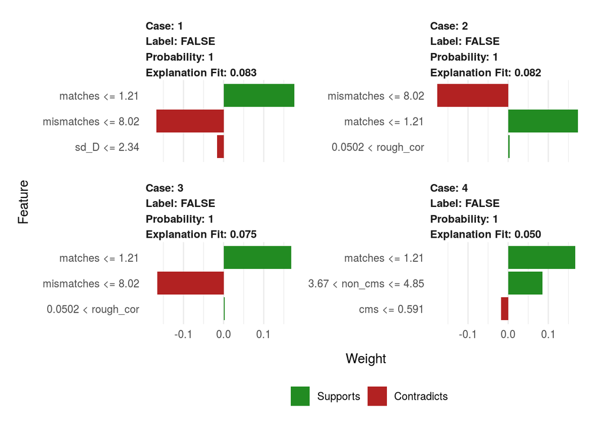

```r
plot_features(lime_explain_mains$explain[1:12,])
```

```r
coefs <- logistic_mains$finalModel$coefficients %>% round(2)
```

The logistic regression model is

$\log\left(\frac{\hat{p}}{1-\hat{p}}\right)=$ -10.02 + 1.53 ccf + -0.06 rough_cor + 0.78 D + -0.31 sd_D + 1.32 matches + -1.07 mismatches + -0.08 cms + 0.82 non_cms + -0.23 sum_peaks

where $\hat{p}=P(\mbox{samesource = TRUE})$.

I started trying to compare the results from LIME to the logistic regression model, but I realized that I need to standardize my test data before I use the model to make predictions.

```r
m = function(x) coefs[2:10] * x
m(hamby224_test[1,] %>% select(rf_features))
```

```
##         ccf   rough_cor           D          sd_D   matches mismatches
## 1 0.4137459 -0.01622533 0.001089166 -0.0006480818 0.7790299  -8.149276
##           cms non_cms  sum_peaks
## 1 -0.04721394 3.12262 -0.3365381
```

```r
hamby224_test[1:4,] %>% select(rf_features)
```

```
##         ccf rough_cor           D        sd_D   matches mismatches
## 1 0.2704221 0.2704221 0.001396367 0.002090586 0.5901742   7.616146
## 2 0.2704221 0.2704221 0.001396367 0.002090586 0.5901742   7.616146
## 3 0.2788290 0.2788290 0.001505819 0.002059285 0.5320479   7.895640
## 4 0.3146965 0.3146965 0.001533943 0.002235877 0.5304097   8.213552
##         cms  non_cms sum_peaks
## 1 0.5901742 3.808073  1.463209
## 2 0.5901742 3.808073  1.463209
## 3 0.5320479 4.462753  1.224632
## 4 0.5304097 4.449008  2.340695
```

```r
coefs
```

```
## (Intercept)         ccf   rough_cor           D        sd_D     matches
##      -10.02        1.53       -0.06        0.78       -0.31        1.32
##  mismatches         cms     non_cms   sum_peaks
##       -1.07       -0.08        0.82       -0.23
```

```r
hamby224_test[1:4,] %>% select(rf_features) * coefs[2:10]
```

```
##           ccf   rough_cor             D          sd_D     matches
## 1  0.41374589  0.35695724 -3.211644e-04 -0.0006480818  0.48394284
## 2 -0.01622533 -0.28935170  2.136441e-03  0.0027595739 -0.13574006
## 3  0.21748662 -0.02230632 -9.034913e-05 -0.0022034349  0.81403330
## 4 -0.09755591  0.25805112  1.196476e-03 -0.0001788702 -0.03182458
##   mismatches         cms    non_cms  sum_peaks
## 1   5.940594 -0.04721394 -0.2284844 -1.5656340
## 2  -2.361005  0.48394284  2.9702970 -0.1170567
## 3  10.422245 -0.12237102 -1.3834535  1.0041978
## 4  -8.788501  0.81152686  5.8726899 -0.5383599
```

```r
mains_test_explain <- hamby224_test %>%
  mutate(case = as.character(case)) %>%
  full_join(lime_explain_mains$explain, by = "case") %>%
  mutate(case = factor(case),
         feature = factor(feature))
```

Below is a plot of the three chosen features for each of the cases faceted by set. The features are ordered by order they were chosen by lime (ordered by magnitude of the coefficients).

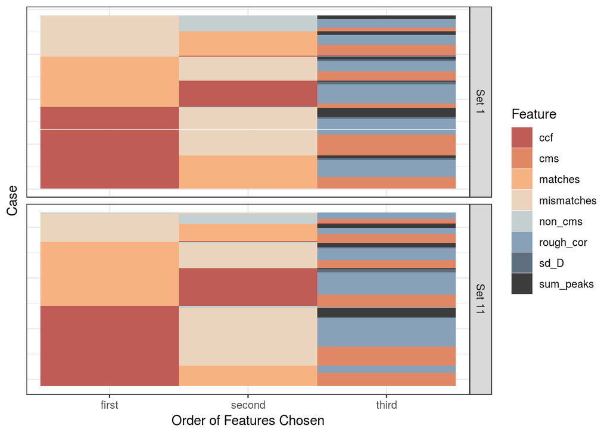

```r
mains_test_explain %>%
  na.omit() %>%
  arrange(case, desc(abs(feature_weight))) %>%
  mutate(feature_order = rep(c("first", "second", "third"), n() / 3)) %>%
  select(case, set, feature, feature_order) %>%
  spread(feature_order, feature) %>%
  arrange(set, first, second, third) %>%
  mutate(order = 1:n()) %>%
  gather(feature_order, feature, 3:5) %>%
  ggplot(aes(x = feature_order, y = order, fill = feature)) +
  geom_tile() +
  facet_grid(set ~ ., scales = "free_y") +
  theme_bw() +
  gretchenalbrecht::scale_fill_gretchenalbrecht(palette = "last_rays", discrete = TRUE) +
  theme(axis.text.y = element_blank(),
        axis.ticks.y = element_blank()) +
  labs(x = "Order of Features Chosen", y = "Case", fill = "Feature")
```

```r
pca_results <- princomp(hamby224_test %>% select(rf_features) %>% na.omit())
pca_results$loadings
```

```
##
## Loadings:
##            Comp.1 Comp.2 Comp.3 Comp.4 Comp.5 Comp.6 Comp.7 Comp.8 Comp.9
## ccf                                            0.703                0.707
## rough_cor                                      0.703               -0.707
## D                                                     0.456 -0.890
## sd_D                                                  0.890  0.456
## matches    -0.453  0.457        -0.331  0.685
## mismatches  0.223 -0.210 -0.530 -0.777 -0.147
## cms        -0.453  0.507 -0.358        -0.627
## non_cms     0.156        -0.762  0.525  0.334
## sum_peaks  -0.717 -0.694
##
##                Comp.1 Comp.2 Comp.3 Comp.4 Comp.5 Comp.6 Comp.7 Comp.8
## SS loadings     1.000  1.000  1.000  1.000  1.000  1.000  1.000  1.000
## Proportion Var  0.111  0.111  0.111  0.111  0.111  0.111  0.111  0.111
## Cumulative Var  0.111  0.222  0.333  0.444  0.556  0.667  0.778  0.889
##                Comp.9
## SS loadings     1.000
## Proportion Var  0.111
## Cumulative Var  1.000
```

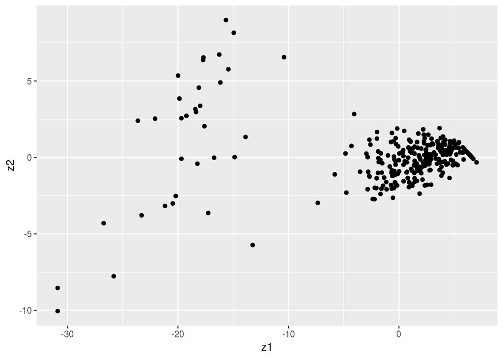

```r
z1 <- pca_results$scores[,1]
z2 <- pca_results$scores[,2]
ggplot(data.frame(z1, z2), aes(x = z1, y = z2)) +
  geom_point()
```

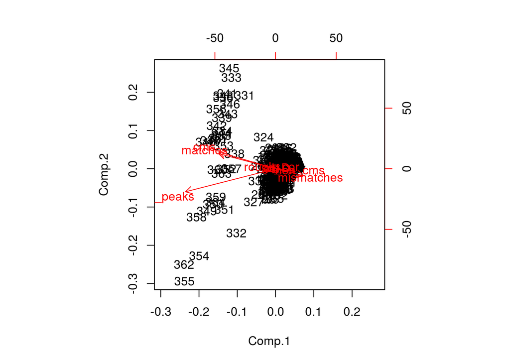

```r
biplot(pca_results)
```

# Visualizing All Input Options

### Comparing Input Values by MSE and $R^2$

In order to assess which lime implementation is doing the best job of capturing the predictions from the random forest model, I decided to calculate the mean squared error for each of the input situations. I defined the mean squared error as
$$\frac{\sum_{i=1}^n (\hat{p}_{\mbox{simple},i}-\hat{p}_{\mbox{complex},i})^2}{n}$$
where $n$ is the number of observations in the testing dataset (within a set). Additionally, I was curious to compare the fits of the ridge regression models across input values, so I calculated the average $R^2$ for each input situation.

```r
# Summarizing lime results
logistic_lime_results <- logistic_lime_comparisons %>%
  filter(!is.na(rfscore)) %>%
  group_by(situation, bin_situation, bin_continuous, quantile_bins, nbins, use_density,
           bin_method, response, set) %>%
  summarise(mse = (sum(diff^2)) / length(diff),
            ave_r2 = mean(model_r2)) %>%
  arrange(set) %>%
  ungroup()
```

The plot below shows the mean squared errors for each of the input situations faceted by set. There is no one bin type that stands out as performing the best across all or most number of bins. This is unlike the results from the random forest model where the tree based bins usually performed the best.

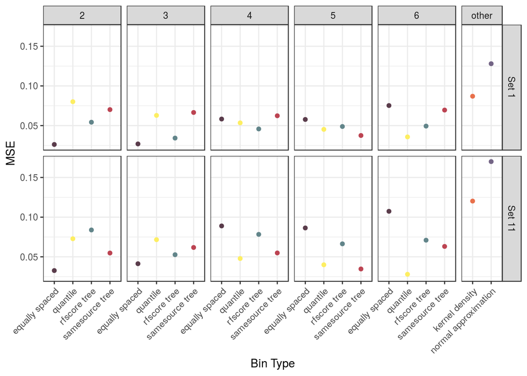

```r
# Plot of MSEs
logistic_lime_results %>%
  mutate(bins = ifelse(nbins == 4 & bin_continuous == FALSE, "other", nbins)) %>%
  ggplot(aes(x = bin_situation, y = mse, color = bin_situation)) +
  geom_point() +
  facet_grid(set ~ bins, scales = "free_x", space = "free_x") +
  theme_bw() +
  theme(axis.text.x = element_text(angle = 45, hjust = 1),
        legend.position = "none") +
  labs(x = "Bin Type", y = "MSE", color = "") +
  scale_color_gretchenalbrecht(palette = "winged_spill", discrete = TRUE)
```

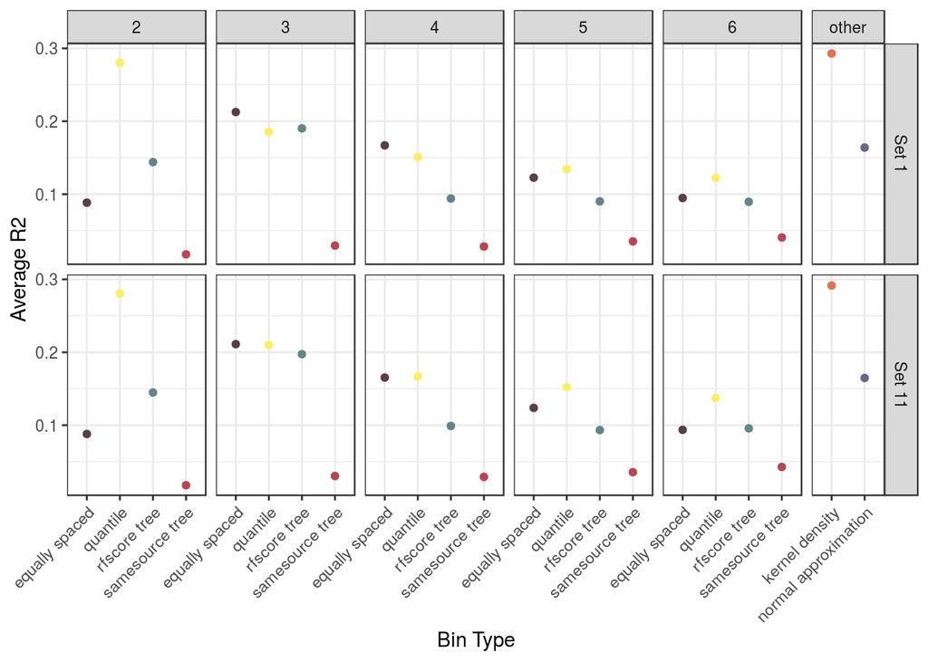

```r
# Plot of R^2s
logistic_lime_results %>%
  mutate(bins = ifelse(nbins == 4 & bin_continuous == FALSE, "other", nbins)) %>%
  ggplot(aes(x = bin_situation, y = ave_r2, color = bin_situation)) +
  geom_point() +
  facet_grid(set ~ bins, scales = "free_x", space = "free_x") +
  theme_bw() +
  theme(axis.text.x = element_text(angle = 45, hjust = 1),
        legend.position = "none") +
  labs(x = "Bin Type", y = "Average R2", color = "") +
  scale_color_gretchenalbrecht(palette = "winged_spill", discrete = TRUE)
```

## Consistency

I wanted to look at the consistency of features chosen by lime across the number of bins within different bin types. I would like the features chosen to not depend on the number of bins used. Otherwise, it will be difficult to know how many bins to use. Additionally, it would be nice if the features chosen differed across cases, so that the explanations are based on the locality of the observation and not general across all locations. The code below creates a dataset that identifies the order in which the features are chosen by lime.

```r
# Creates a dataset that creates columns of the chosen features by lime from first to third
logistic_chosen_features <- logistic_test_explain %>%
  filter(!(bin_situation %in% c("kernel density", "normal approximation"))) %>%
  filter(!is.na(rfscore)) %>%
  select(set, situation, bin_situation, nbins, case, samesource, feature, feature_weight) %>%
  mutate(feature_weight_abs = abs(feature_weight)) %>%
  arrange(situation, case, desc(feature_weight_abs)) %>%
  mutate(explainer = rep(c("first", "second", "third"), length(situation) / 3)) %>%
  select(-feature_weight, -feature_weight_abs) %>%
  spread(explainer, feature)
```

### Fleiss’s Kappa

In order to access consistency, I have decided to compute Fleiss’ kappa for each of the bin types. Fleiss’ kappa is often used to assess the consistency across raters for any number of raters and with nominal ratings. It calculates the degree of agreement in classification over that which would be expected by chance. A description of how it is computed can be found on the wikipedia site: https://en.wikipedia.org/wiki/Fleiss%27_kappa

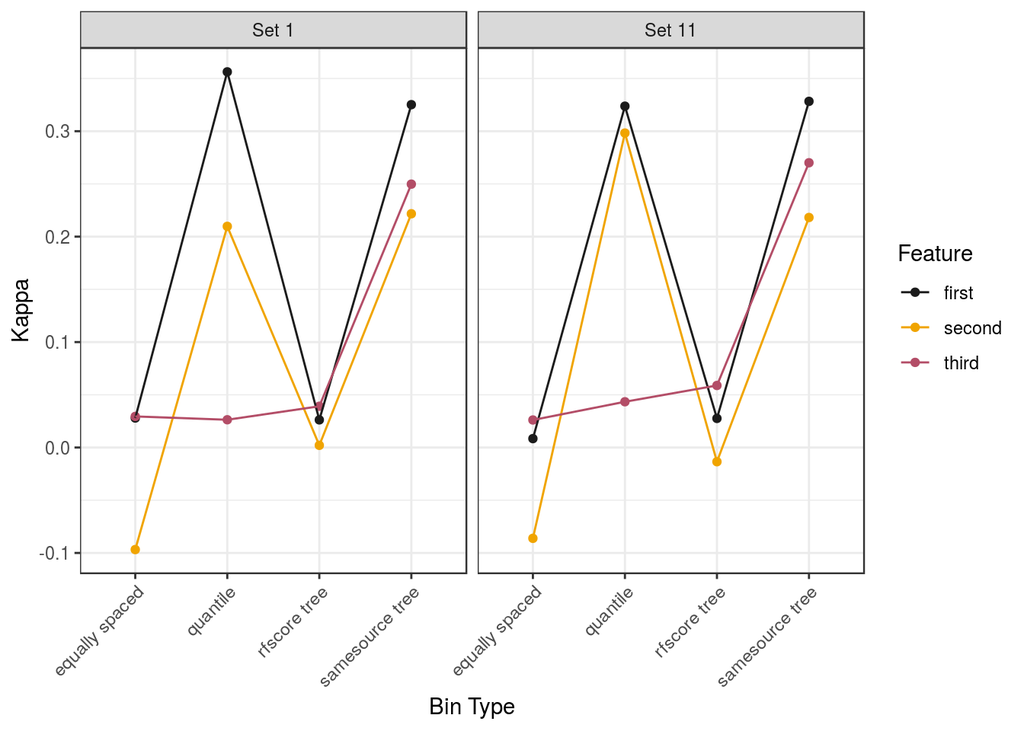

```r
# Computes and plots the values of kappa
logistic_chosen_features %>%
  ungroup() %>%
  select(-situation) %>%
  gather(key = chosen, value = feature, first:third) %>%
  spread(nbins, feature) %>%
  select(-case) %>%
  rename(bins2 = "2", bins3 = "3", bins4 = "4", bins5 = "5", bins6 = "6") %>%
  group_by(set, bin_situation, chosen) %>%
  summarise(kappa =
              irr::kappam.fleiss(matrix(c(bins2, bins3, bins4, bins5, bins6),
                                        ncol = 5))$value) %>%
  arrange(chosen, set, bin_situation) %>%
  ggplot(aes(x = bin_situation, y = kappa, color = chosen, group = chosen)) +
  geom_point() +
  geom_line() +
  facet_grid( ~ set) +
  theme_bw() +
  theme(axis.text.x = element_text(angle = 45, hjust = 1)) +
  scale_color_gretchenalbrecht(palette = "pink_cloud", discrete = TRUE) +
  labs(x = "Bin Type", y = "Kappa", color = "Feature")
```

### Tile Plots of Features Chosen

I also attempted to plot the features chosen by lime in order to visually assess the consistency. This plots are included below. The results appear to be different from the random forest results, but it is still possible to se vertical stripes that suggest a global interpretation as opposed to a local interpretation. However, the samesource bins do have some horizontal stipes that show what we would like to see. It is also interesting to note that the vertical bins are the most pronounced with the rfscore tree. This does not suprise me considering that these explanations are for a logistic regression and not the random forest model.

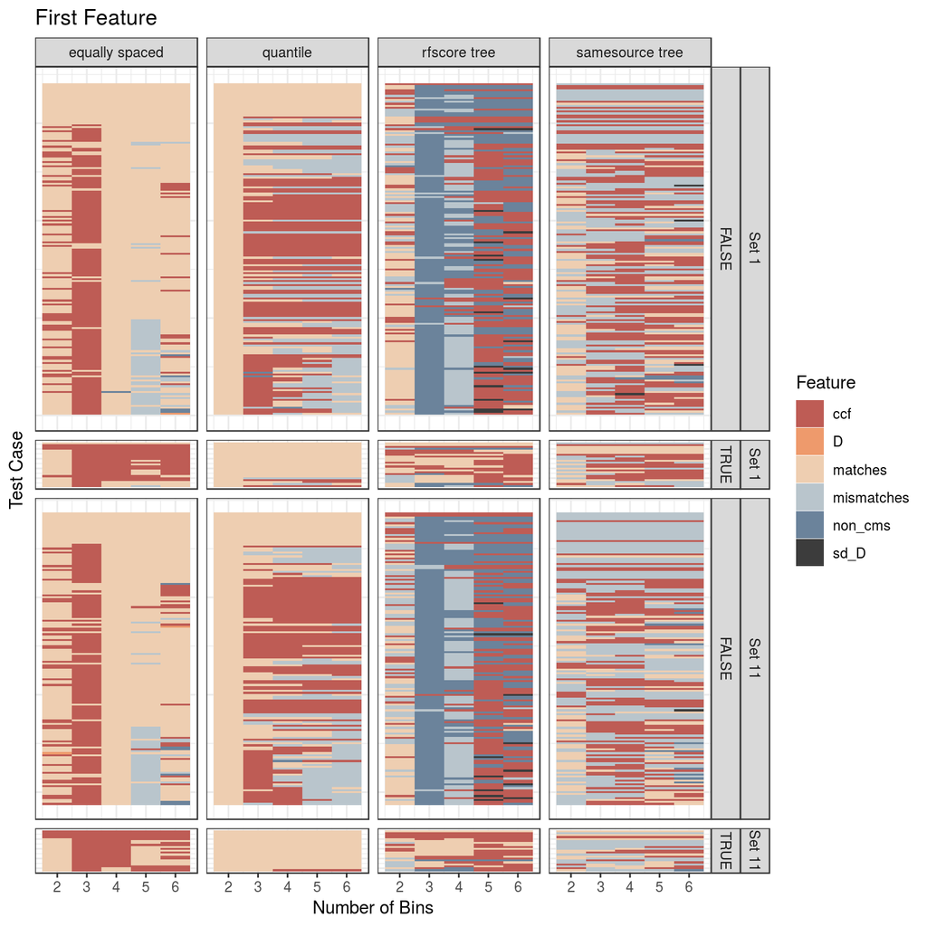

```r
# Plots the top feature for each case for each bin situation
logistic_chosen_features %>%
  group_by(bin_situation, case) %>%
  mutate(nlevels = length(levels(factor(first)))) %>%
  ungroup() %>%
  arrange(bin_situation, set, samesource, desc(nlevels), case) %>%
  mutate(order = rep(rep(1:length(unique(case)), each = 5, 4))) %>%
  ggplot(aes(x = nbins, y = order, fill = first)) +
  geom_tile() +
  facet_grid(set + samesource ~ bin_situation, scales = "free", space = "free_y") +
  theme_bw() +
  theme(axis.text.y = element_blank(),
        axis.ticks.y = element_blank()) +
  scale_fill_gretchenalbrecht(palette = "last_rays", discrete = TRUE) +
  labs(x = "Number of Bins", y = "Test Case", fill = "Feature", title = "First Feature")
```

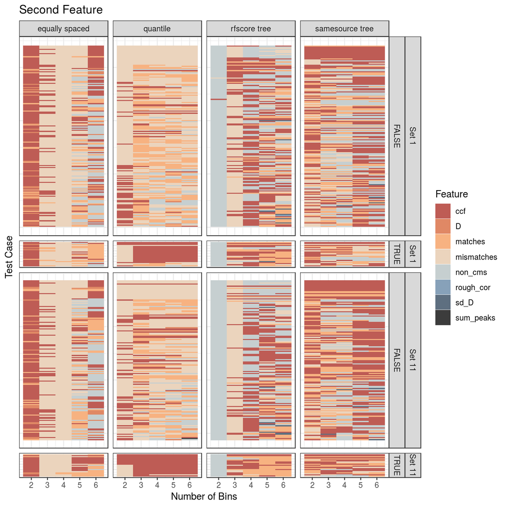

```r
# Plots the second feature for each case for each bin situation
logistic_chosen_features %>%
  group_by(bin_situation, case) %>%
  mutate(nlevels = length(levels(factor(second)))) %>%
  ungroup() %>%
  arrange(bin_situation, set, samesource, desc(nlevels), case) %>%
  mutate(order = rep(rep(1:length(unique(case)), each = 5, 4))) %>%
  ggplot(aes(x = nbins, y = order, fill = second)) +
  geom_tile() +
  facet_grid(set + samesource ~ bin_situation, scales = "free", space = "free_y") +
  theme_bw() +
  theme(axis.text.y = element_blank(),
        axis.ticks.y = element_blank()) +
  scale_fill_gretchenalbrecht(palette = "last_rays", discrete = TRUE) +
  labs(x = "Number of Bins", y = "Test Case", fill = "Feature", title = "Second Feature")
```

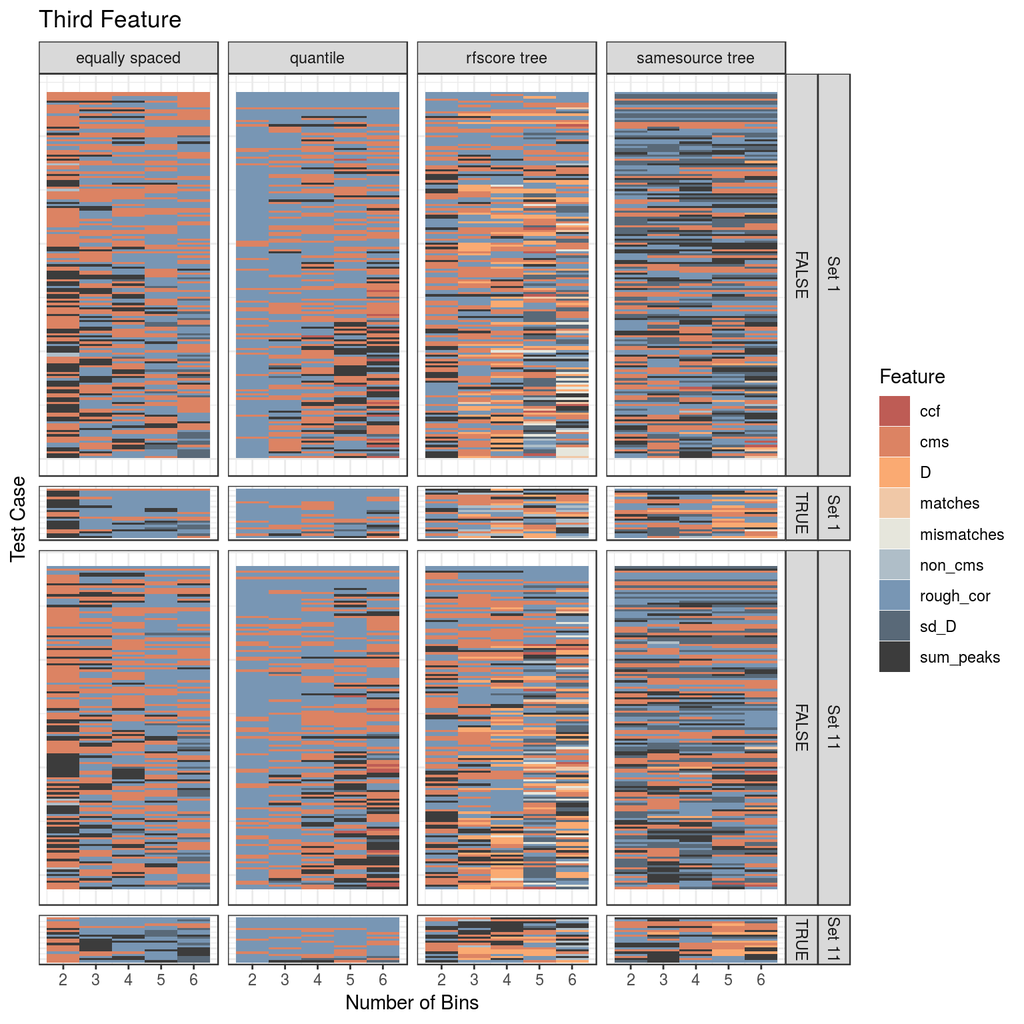

```r
# Plots the third feature for each case for each bin situation
logistic_chosen_features %>%
  group_by(bin_situation, case) %>%
  mutate(nlevels = length(levels(factor(third)))) %>%
  ungroup() %>%
  arrange(bin_situation, set, samesource, desc(nlevels), case) %>%
  mutate(order = rep(rep(1:length(unique(case)), each = 5, 4))) %>%
  ggplot(aes(x = nbins, y = order, fill = third)) +
  geom_tile() +
  facet_grid(set + samesource ~ bin_situation, scales = "free", space = "free_y") +
  theme_bw() +
  theme(axis.text.y = element_blank(),
        axis.ticks.y = element_blank()) +
  scale_fill_gretchenalbrecht(palette = "last_rays", discrete = TRUE) +
  labs(x = "Number of Bins", y = "Test Case", fill = "Feature", title = "Third Feature")
```